# Democratic Error in Polling

Haley Reed

7/1/2020

**Introduction**

To understand pollster bias, we can use a Bayesian modeling to describe metric data as function of nominal predictors, similar to traditional ANOVA modeling. We will do so with using pollster data compiled by FiveThirtyEight. Here, we will explore how the specific pollster, in conjuction with the year, can act as an explanatory variable to predict bias present in individual polls.

It is of interest to include these nominal predictor of pollster because there is a historical precedent for bias due to systematic polling error and housing effects, as well as growing evidence that these biases change year by year (Rakich 2019).

In this analysis, we will be focusing on specifically on democratic bias. Let’s take a moment to define what that is. We often think of bias in terms of the margin between democrats and republicans, however it is worth (for the purposes of this analysis) defining in it more in terms of democratic error.

$$DemocraticBias = DemocraticCanditatePollingPercent-DemocraticActualPercentage$$

**The Model** The Bayesian hierarchical implemented here starts with generic noncommittal parameters. We use all vague priors as to not greatly influence the posterior distribution.

The model diagram can be seen below:

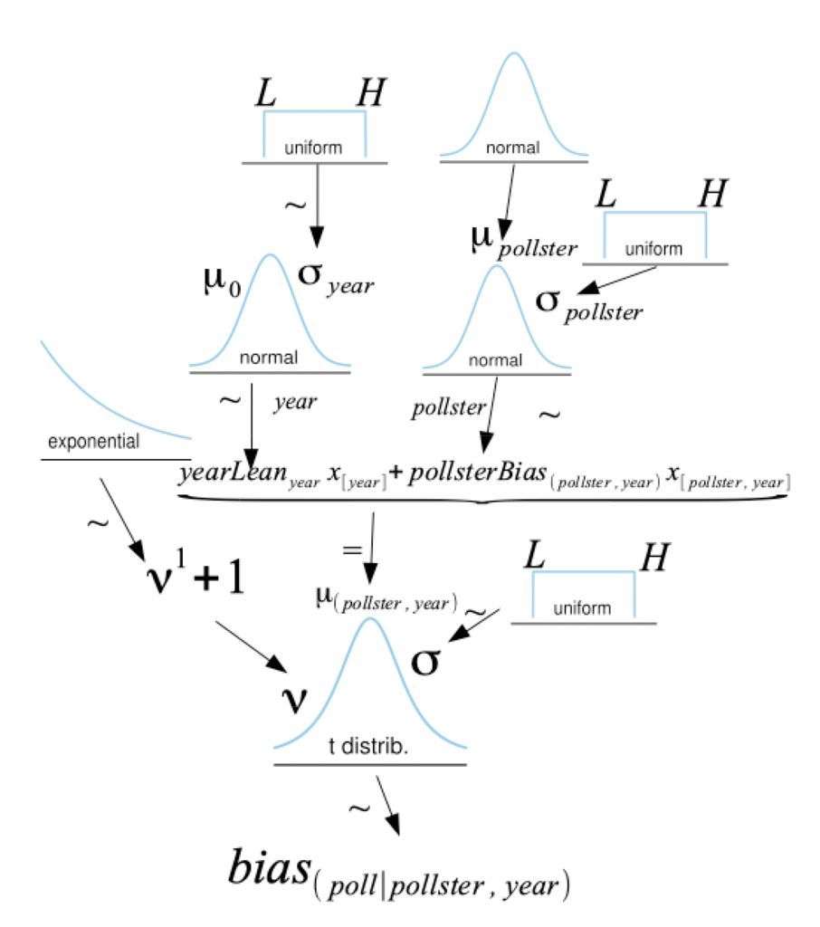

While we can avoid sampling variability assumptions with Bayesian Analysis, it is necessary to check for proper convergence of the MCMC chains. In running this analysis, all parameters should be checked for convergence. A test for convergence of the intercept for the 2000 election year can be seen below.

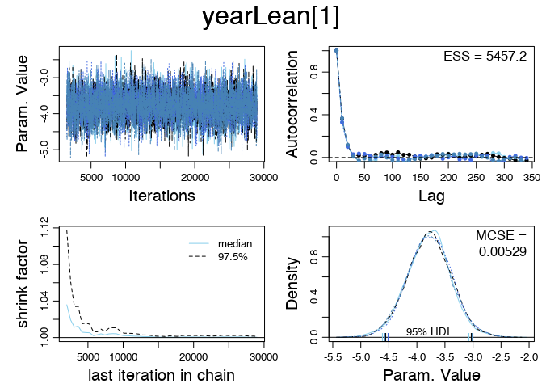

The density plots are sufficiently converged after the burn-in period, the autocorrelation appears small enough, and there is nothing in these plots that suggest it would not be safe to continue with the Bayesian analysis.

In the posterior distributions below you can see the effects of shrinkage:

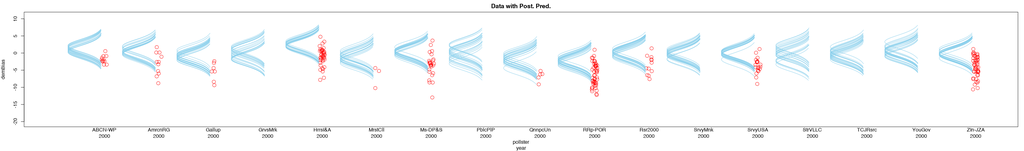

A posterior predictive plot comparing the selected pollsters’ bias in 2000.

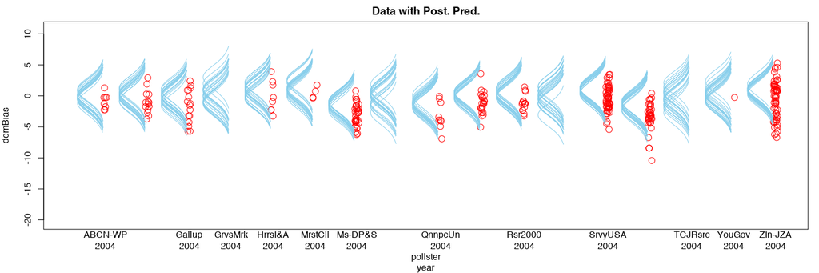

A posterior predictive plot comparing the selected pollsters’ bias in 2004.

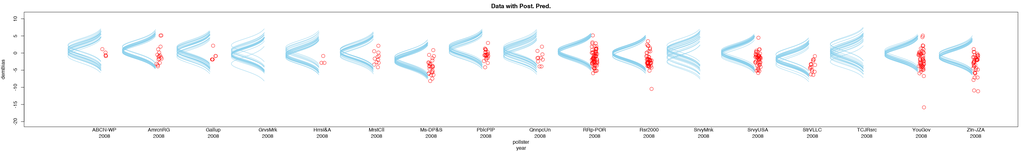

A posterior predictive plot comparing the selected pollsters’ bias in 2008.

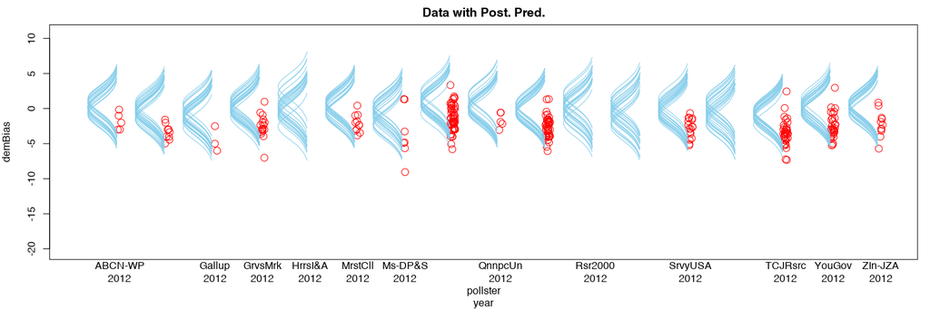

A posterior predictive plot comparing the selected pollsters’ bias in 2012.

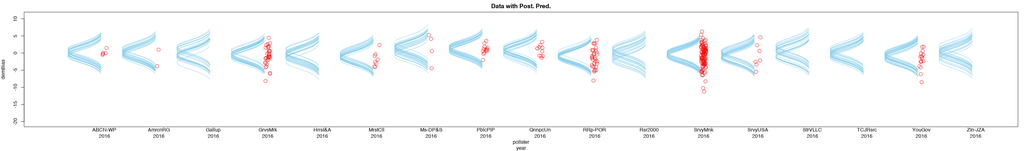

A posterior predictive plot comparing the selected pollsters’ bias in 2016.

In addition to these posterior predictive plots, we can take at the year posterior plots and see the Highest Density intervals for each year. Here, you can see the variation between years. 2016 had the greatest amount of democratic bias (although still negative because of the amount of undecided voters), while 2000 was notably less bias towards democrats.

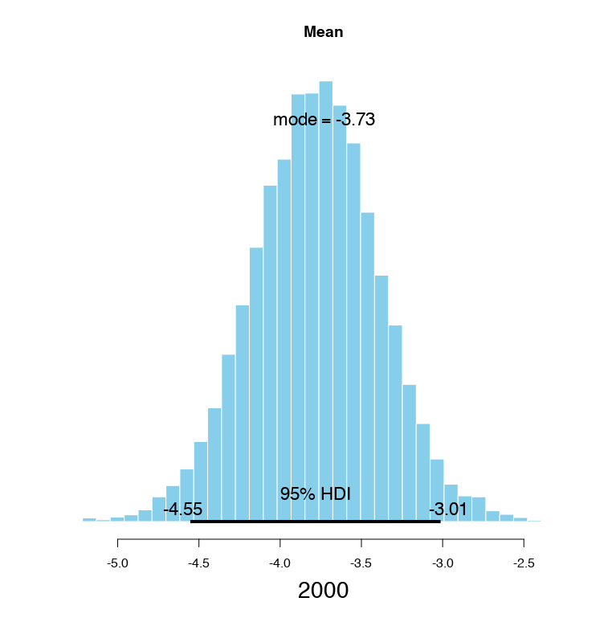

A posterior plot looking at the most credible values for democratic bias in the 2000 presidential election.

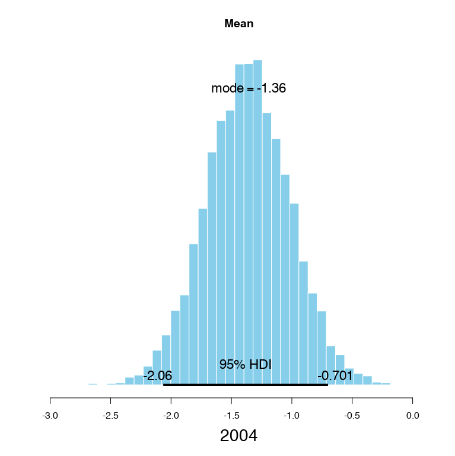

A posterior plot looking at the most credible values for democratic bias in the 2004 presidential election.

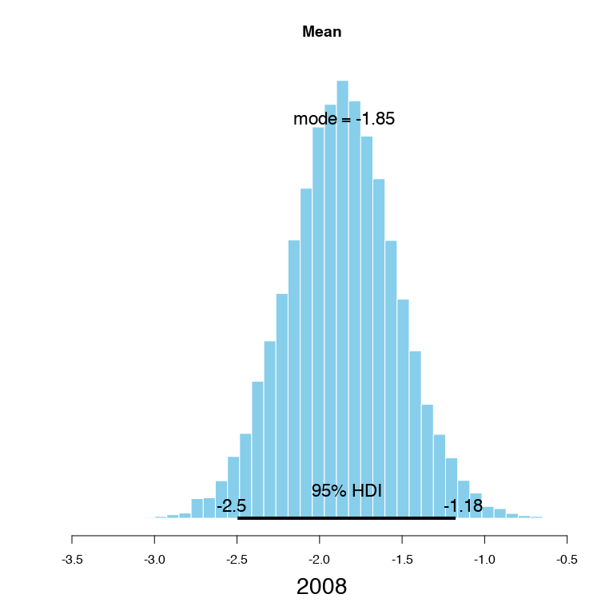

A posterior plot looking at the most credible values for democratic bias in the 2008 presidential election.

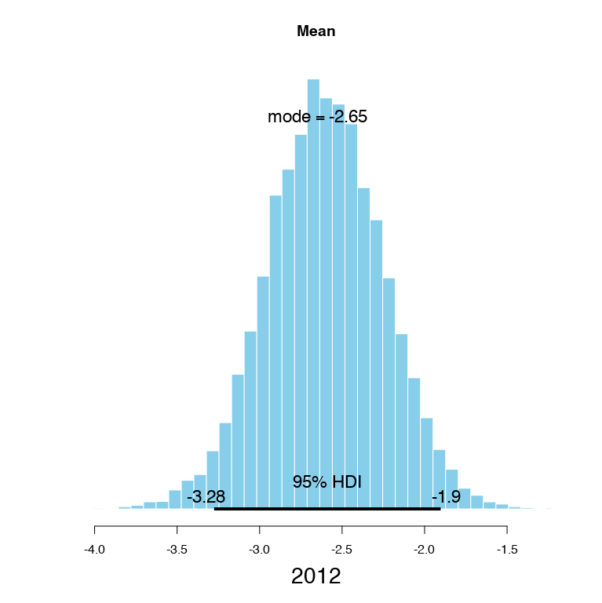

A posterior plot looking at the most credible values for democratic bias in the 2012 presidential election.

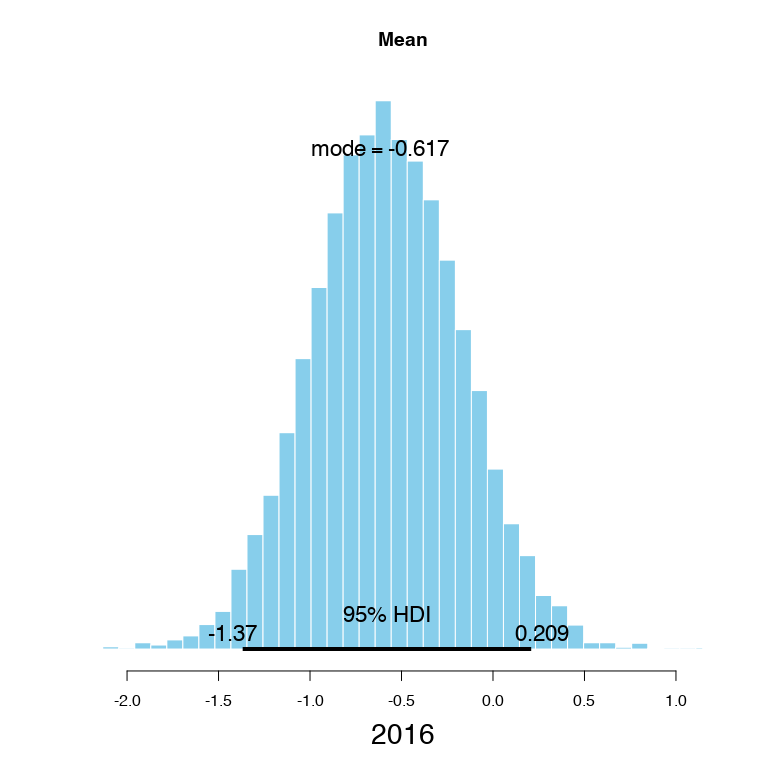

A posterior plot looking at the most credible values for democratic bias in the 2016 presidential election.

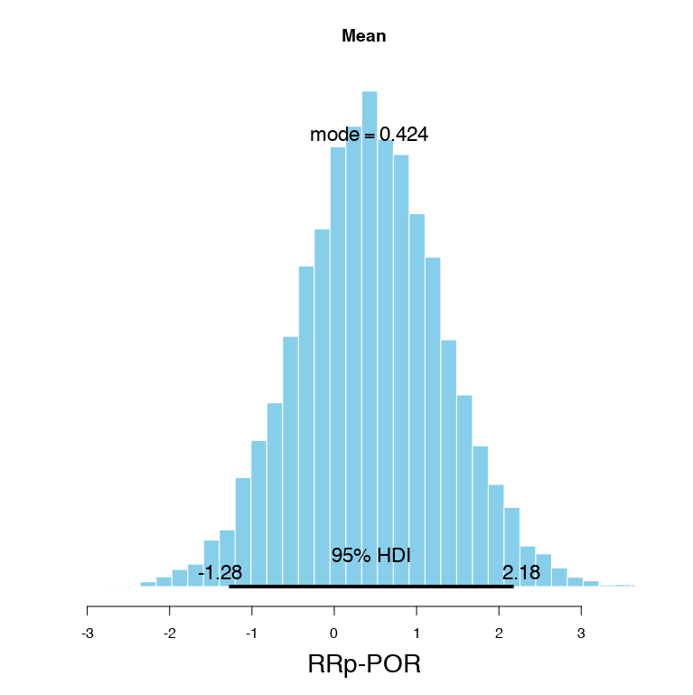

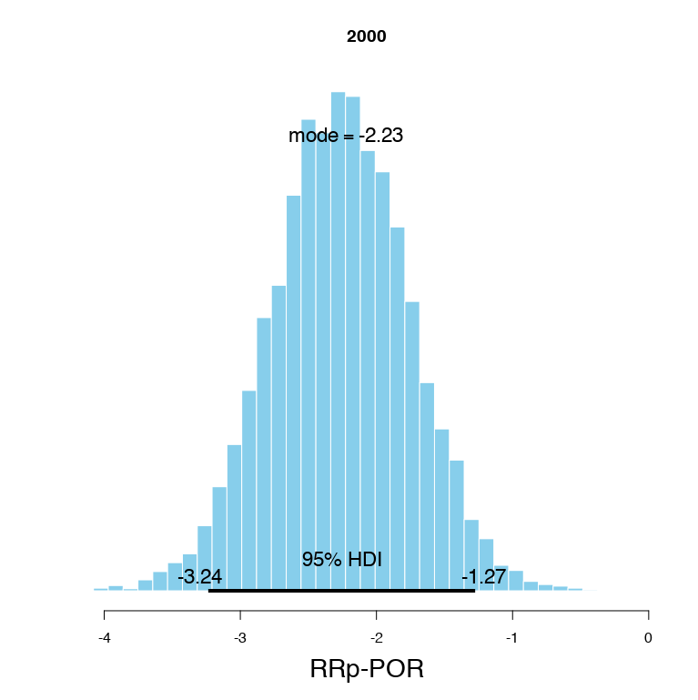

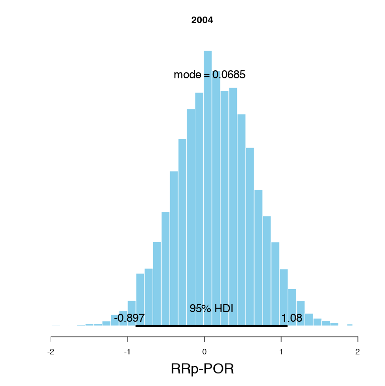

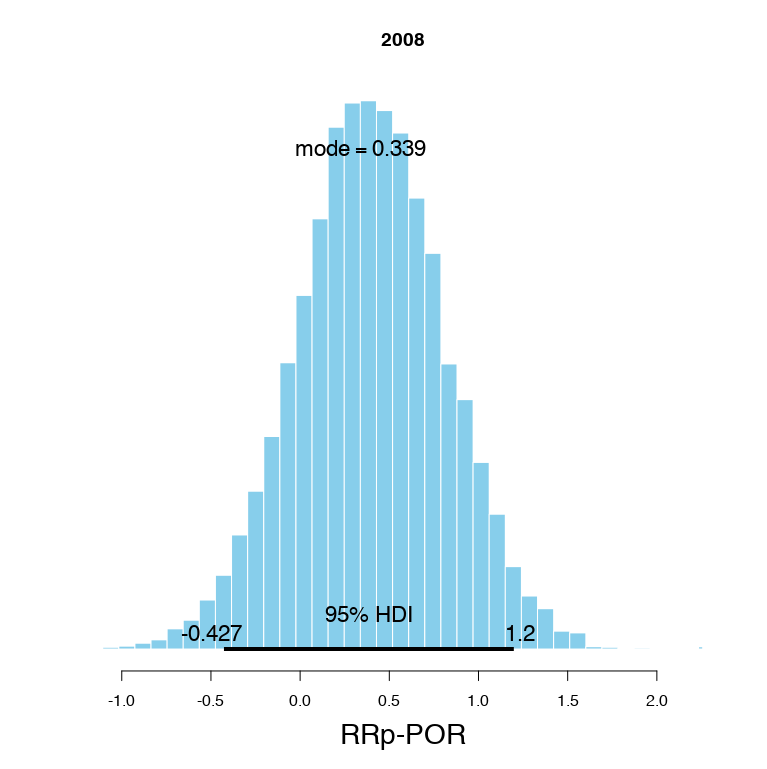

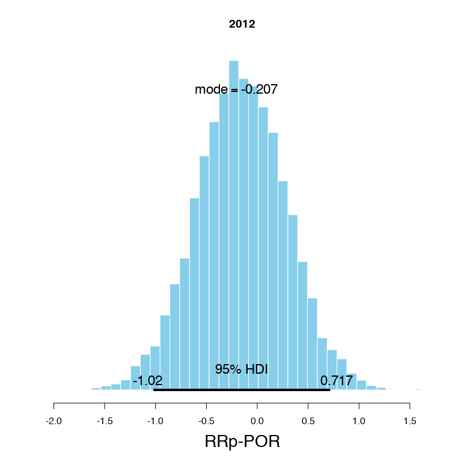

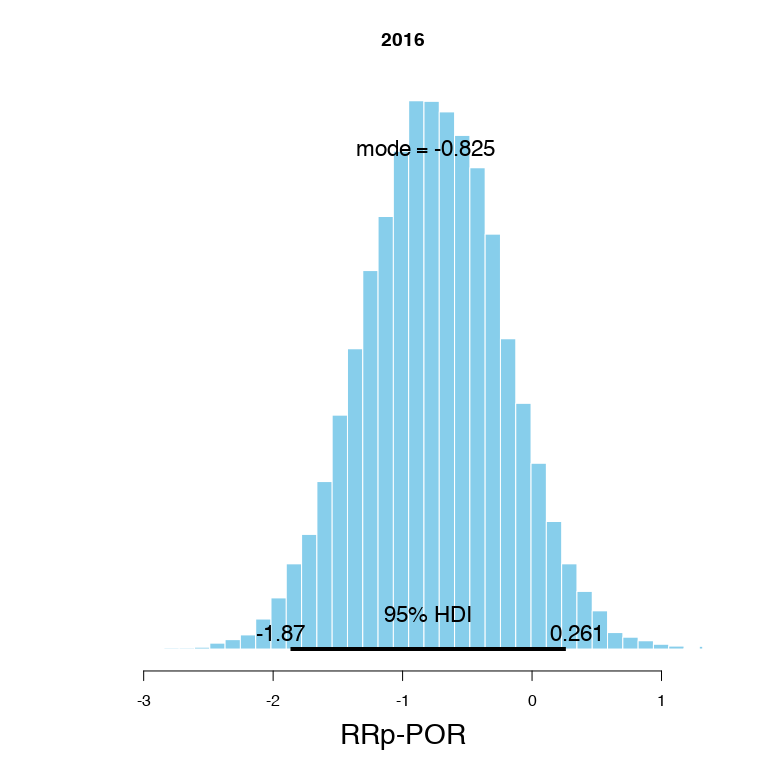

The most credible values and the highest density intervals for each parameter value can be seen below:

|  | Mean | Median | Mode | ESS | HDImass | HDIlow | HDIhigh |
| --- | --- | --- | --- | --- | --- | --- | --- |
| biasSpread | 2.0685521 | 2.0684200 | 2.0718842 | 9725.0 | 0.95 | 1.9332400 | 2.2069900 |
| nuY | 7.7403834 | 7.4604600 | 6.8694303 | 9833.4 | 0.95 | 5.0590800 | 11.2733000 |
| pollsterSpread | 1.1038590 | 1.0959750 | 1.0668390 | 10149.0 | 0.95 | 0.8486320 | 1.3861100 |
| yearSpread | 3.2775092 | 2.8608950 | 2.3062572 | 9388.8 | 0.95 | 1.2146600 | 6.3429800 |
| yearLean[1] | -3.7799624 | -3.7767500 | -3.7305514 | 5674.7 | 0.95 | -4.5532400 | -3.0124400 |
| yearLean[2] | -1.3654764 | -1.3650000 | -1.3591176 | 4703.0 | 0.95 | -2.0644800 | -0.7008010 |
| yearLean[3] | -1.8636281 | -1.8620250 | -1.8522716 | 4309.7 | 0.95 | -2.4967600 | -1.1757100 |
| yearLean[4] | -2.6025667 | -2.6043300 | -2.6485291 | 4886.8 | 0.95 | -3.2758500 | -1.9027200 |
| yearLean[5] | -0.5799052 | -0.5830995 | -0.6174489 | 5203.7 | 0.95 | -1.3680600 | 0.2088810 |
| pollsterBias[1,1] ABCN-WP 2000 | 1.4408139 | 1.4330450 | 1.4295507 | 8357.4 | 0.95 | 0.2619080 | 2.6201500 |
| pollsterBias[2,1] AmrcnRG 2000 | 0.5136734 | 0.5083765 | 0.4495258 | 10072.5 | 0.95 | -0.8197300 | 1.9260200 |
| pollsterBias[3,1] Gallup 2000 | -0.8789707 | -0.8660955 | -0.7916985 | 9717.4 | 0.95 | -2.2722500 | 0.5946360 |
| pollsterBias[4,1] GrvsMrk 2000 | -0.0102074 | -0.0121199 | -0.1026302 | 11000.0 | 0.95 | -2.1185200 | 2.2488800 |
| pollsterBias[5,1] HrrsI&A 2000 | 2.5697337 | 2.5575750 | 2.5132246 | 6753.4 | 0.95 | 1.6220400 | 3.5760200 |
| pollsterBias[6,1] MrstCll 2000 | -0.9329373 | -0.9185890 | -0.8219144 | 11000.0 | 0.95 | -2.6918100 | 0.8604900 |
| pollsterBias[7,1] Ms-DP&S 2000 | 0.3076264 | 0.3111890 | 0.3747545 | 8027.9 | 0.95 | -0.7758630 | 1.3809700 |
| pollsterBias[8,1] PblcPlP 2000 | 0.0159333 | 0.0134942 | -0.0962156 | 11000.0 | 0.95 | -2.1549700 | 2.2520000 |
| pollsterBias[9,1] QnnpcUn 2000 | -1.6475359 | -1.6371350 | -1.5853362 | 10097.7 | 0.95 | -3.1032500 | 0.0080047 |
| pollsterBias[10,1] RRp-POR 2000 | -2.2629633 | -2.2618650 | -2.2251702 | 6953.2 | 0.95 | -3.2355800 | -1.2748600 |
| pollsterBias[11,1] Rsr2000 2000 | 0.1494848 | 0.1486270 | 0.0793601 | 9003.4 | 0.95 | -1.1226700 | 1.4155300 |
| pollsterBias[12,1] SrvyMnk 2000 | -0.0069656 | -0.0145053 | 0.1433570 | 11000.0 | 0.95 | -2.2618900 | 2.2068800 |
| pollsterBias[13,1] SrvyUSA 2000 | 0.0604653 | 0.0526438 | -0.0331718 | 8275.0 | 0.95 | -1.0262300 | 1.1701400 |
| pollsterBias[14,1] StrVLLC 2000 | 0.0186686 | 0.0053265 | -0.1220899 | 11000.0 | 0.95 | -2.2672000 | 2.1192900 |
| pollsterBias[15,1] TCJRsrc 2000 | -0.0080758 | 0.0016942 | 0.0919764 | 11394.2 | 0.95 | -2.2604300 | 2.0993500 |
| pollsterBias[16,1] YouGov 2000 | 0.0036477 | -0.0046743 | -0.1541574 | 11000.0 | 0.95 | -2.2431900 | 2.1650300 |
| pollsterBias[17,1] ZIn-JZA 2000 | 0.0126213 | 0.0077597 | 0.0157641 | 6758.1 | 0.95 | -0.9297890 | 1.0004800 |
| pollsterBias[1,2] ABCN-WP 2004 | 0.3210848 | 0.3193255 | 0.2202602 | 9580.4 | 0.95 | -1.0164300 | 1.5524800 |
| pollsterBias[2,2] AmrcnRG 2004 | 0.1968547 | 0.1920710 | 0.2033906 | 9045.7 | 0.95 | -0.9309020 | 1.3599400 |
| pollsterBias[3,2] Gallup 2004 | -0.3117473 | -0.3116385 | -0.2936643 | 8240.7 | 0.95 | -1.4628200 | 0.8291700 |
| pollsterBias[4,2] GrvsMrk 2004 | 0.0158847 | 0.0233122 | -0.0566987 | 11000.0 | 0.95 | -2.1873700 | 2.1805600 |

[output cut: 64 more lines]

**Conclusion**

Contextually, this means for polls analyzed in this model, the polls undercut democrats 2.5044942 percentage points on average.

Using FiveThirtyEight’s data, this Bayesian model with the nominal predictors of pollster and year can determine poll bias for any given poll. Using this model, we found that pollsters have different bias and different magnitudes of that bias. Similarly, bias changes with the year. ## Works Cited

Kruschke, John. 2010. *Doing Bayesian Data Analysis: A Tutorial with R, Jags, and Stan*. Academic Press.

Rakich, Nathaniel. 2019. “How to Read 2020 Polls Like a Fivethirtyeighter.” Edited by FiveThirtyEight. https://fivethirtyeight.com/features/how-to-read-2020-polls-like-a-fivethirtyeighter/.

Silver, Nate. 2020. “Raw Polls.” GitHub. https://github.com/fivethirtyeight/data/blob/master/pollster-ratings/raw-polls.csv.